# Credit Attrition Prediction

## Starting our Predictions

Now that we have a final model, we can start the prediction process! Using our reduced model, we can predict Attrition_Flag in our test data. First, we can generate probabilities of Attrition_Flag given our model.

```r
#now we use our reduced model to generate probabilities of Attrition
probs <- fit_red %>% predict(credit_test, type="response")
```

The tricky part about this prediction is figuring out at what probability do we consider large enough to say this is prediction an Attrited customer, or an Existing customer. Of course, it’s difficult to obtain a probability of 1 that a customer is Existing or Attrited, but there may be a probability that seems to correspond well with the real Attrition found in our test data.

For investigatory purposes, we’ll say if a probability is >= 0.5 that it accurately predicts a customer is Existing, but we can investigate this cut-off a bit further. We can then use these prediction with a cut-off of 0.5 to compare them to the true Attrition_Flag variable to determine how accurate these prediction are.

```r
#there's not really a logical cut-off for what a "good" probability is (yet), so we'll use 0.5 just to see what happes
pred_classes <- ifelse(probs >= .5, 1, 0) #if the prob is >= 0.5, we say it predicts Attrition_Flag at 1

#we can then figure our how well these predictions align with our test dataset
mean(pred_classes == credit_test$Attrition_Flag)
```

```
## [1] 0.9249506
```

```r
#this is a high number, but we're not sure how many false-positives exist here. we'll procede with a ROC analysis
```

It appears that a large proportion of our Attrition_Flag variable was accurately predicted! However, simply counting the proportion of 1s and 0s in our test and predicted data is not our best option. By doing this, we may be over counting false-positives, which doesn’t really help in the true application of our model for prediction (we want as accurate predictions for individuals as possible!). This can be investigated further with ROC and finding the AUV of the ROC.

## ROC and AUC of ROC.

First, let’s generate a ROC and AUC of ROC using our arbitrary cut-off of 0.5. We want the ROC to have a steep start, and then level off as it approaches 1. The AUC (or Area Under the Curve) of the ROC will give us a measure of our true positive rate in our predictions, which really helps show us how accurate our model truly is.

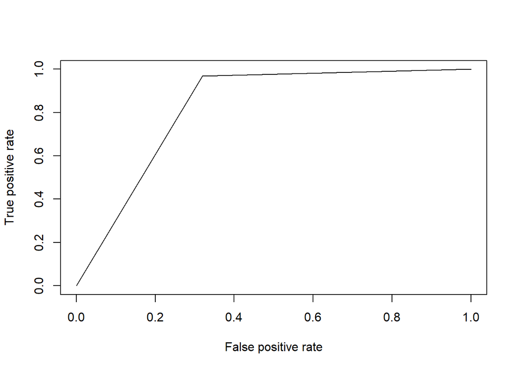

```r
#Using a ROC curve can allow for a deeper look at how well our predictions are doing. We'll go ahead and analyze the ROC curve at a cut-off of .5

pr <- prediction(pred_classes, credit_test$Attrition_Flag) #again, predicting with prob cut-off of .5
perf <- performance(pr, measure = "tpr", x.measure = "fpr")  #determining how well these predictions perform

plot(perf) #plotting our performation in a ROC curve
```

```r
auc(credit_test$Attrition_Flag, pred_classes) #how well does it do? a larger value shows better performance.
```

```
## [1] 0.8246388
```

This ROC and corresponding AUC of the ROC seem good, but we should test other potential probability cut-offs to see if there are better cut-offs to use in our prediction assignment.

## Investigating Many Possible Cut-offs

We’ll parse through all possible probabilities from 0 to 1, separating each probability by 0.01, and then investigate the AUC of the ROC for each probability cut-off and determine which probability gives us the largest AUC.

```r
#now, we can generate area under the curve (AUC) values for various possible cut-off since we really don't know which is best.
possible_probs <- seq(0, 1, .01) #create possible cut-offs from 0-1 seqenced by .01
AUCs <- rep(NA, length(possible_probs)) #creating empty vector for future AUC values

#we can look through our possible cut-offs
for( i in 1:length(possible_probs)) {

  pred_classes <- ifelse(probs >= possible_probs[i], 1, 0) #use ith cut-off prob
  AUCs[i] <- auc(credit_test$Attrition_Flag, pred_classes) #store the AUC

  if( i == length(possible_probs)) { #when the loop is finished

    print(max(AUCs)) #print the best AUC
    print(possible_probs[which.max(AUCs)]) #and the corresponding cut-off

  }

}
```

```
## [1] 0.8783866
## [1] 0.78
```

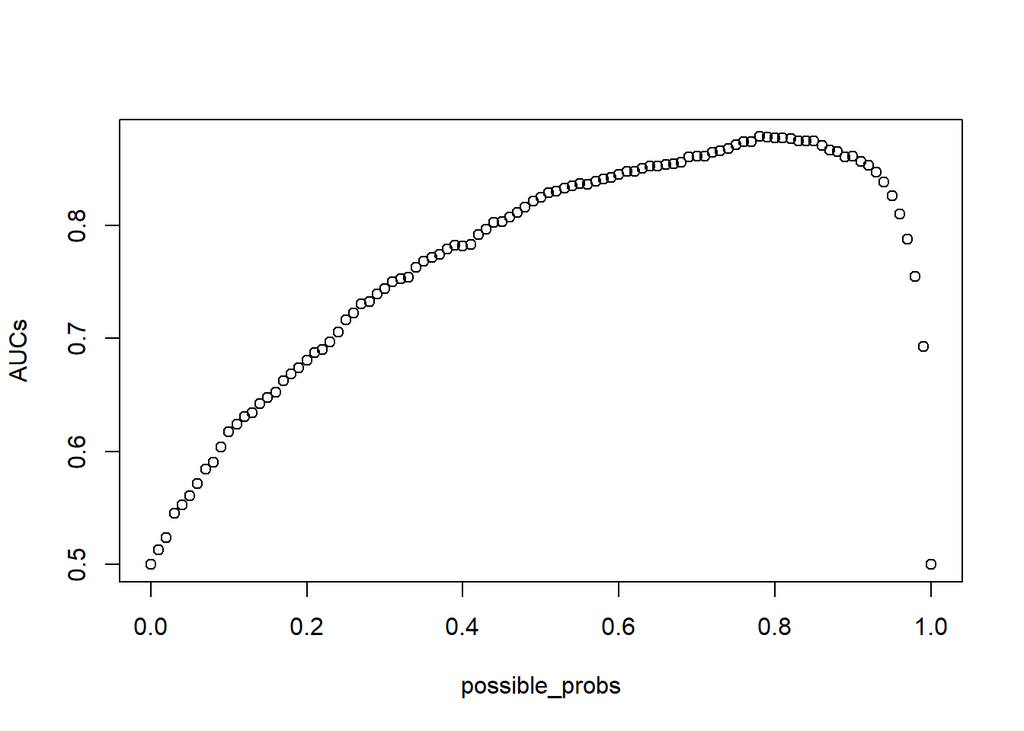

```r
plot(possible_probs, AUCs) #let's see the AUCs for each possible cut-off
```

Interesting graph, but now that we have a final, best cut-off, let’s build our final prediction with this new cut-offs.

```r
pred_classes <- ifelse(probs >= possible_probs[which.max(AUCs)], 1, 0) #now we predict with our best cut-off

mean(pred_classes == credit_test$Attrition_Flag) #lower matching, but better AUC
```

```
## [1] 0.8989467
```

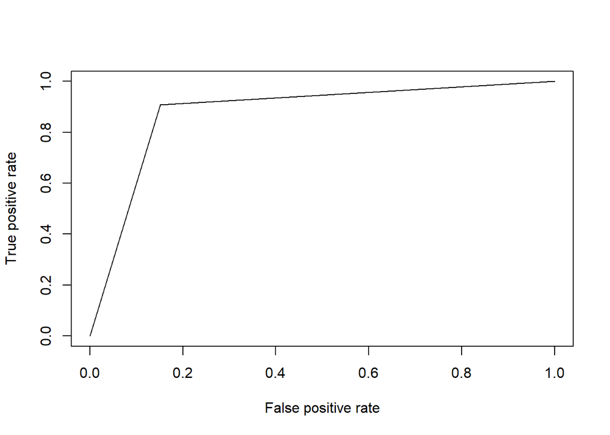

```r
pr <- prediction(pred_classes, credit_test$Attrition_Flag) #predict again for new ROC
perf <- performance(pr, measure = "tpr", x.measure = "fpr") #determine how new predictions perform

plot(perf) #plot our ROC
```